# WGCNA

Mayela Fosado

23/3/2022

# **a) Instalar la librería**

```r
# BiocManager::install("WGCNA")

library(WGCNA)
```

# **b) Construir red de co-expresión a partir del tutorial**

**Link del tutorial:** https://horvath.genetics.ucla.edu/html/CoexpressionNetwork/Rpackages/WGCNA/Tutorials/index.html

Base de datos sobre mediciones de la expresión génica de hígados de ratones hembras y machos.

## 1. Introducción & Limpieza

### **1a. Cargar los datos de expresión**

Configuración importante.

```r
options(stringsAsFactors = F)
```

Cargar las bases de datos.

```r
female <- read.csv("LiverFemale3600.csv")

male <- read.csv("LiverMale3600.csv")
```

Visualizar la información.

```r
# Dimensiones de la base de datos:

dim(female)
```

```
## [1] 3600  143
```

```r
dim(male)
```

```
## [1] 3600  132
```

```r
# Nombres

names(female)
```

```
##   [1] "substanceBXH"   "gene_symbol"    "LocusLinkID"    "ProteomeID"
##   [5] "cytogeneticLoc" "CHROMOSOME"     "StartPosition"  "EndPosition"
##   [9] "F2_2"           "F2_3"           "F2_14"          "F2_15"
##  [13] "F2_19"          "F2_20"          "F2_23"          "F2_24"
##  [17] "F2_26"          "F2_37"          "F2_42"          "F2_43"
##  [21] "F2_45"          "F2_46"          "F2_47"          "F2_48"
##  [25] "F2_51"          "F2_52"          "F2_54"          "F2_63"
##  [29] "F2_65"          "F2_66"          "F2_68"          "F2_69"
##  [33] "F2_70"          "F2_71"          "F2_72"          "F2_78"
##  [37] "F2_79"          "F2_80"          "F2_81"          "F2_83"
##  [41] "F2_86"          "F2_87"          "F2_88"          "F2_89"
##  [45] "F2_107"         "F2_108"         "F2_109"         "F2_110"
##  [49] "F2_111"         "F2_112"         "F2_117"         "F2_119"
##  [53] "F2_125"         "F2_126"         "F2_127"         "F2_141"
##  [57] "F2_142"         "F2_143"         "F2_144"         "F2_145"
```

[output cut: 21 more lines]

```r
names(male)
```

```
##   [1] "substanceBXH"   "gene_symbol"    "LocusLinkID"    "ProteomeID"
##   [5] "cytogeneticLoc" "CHROMOSOME"     "StartPosition"  "EndPosition"
##   [9] "F2_4"           "F2_5"           "F2_6"           "F2_7"
##  [13] "F2_8"           "F2_9"           "F2_10"          "F2_13"
##  [17] "F2_16"          "F2_17"          "F2_18"          "F2_22"
##  [21] "F2_27"          "F2_28"          "F2_29"          "F2_30"
##  [25] "F2_33"          "F2_34"          "F2_35"          "F2_39"
##  [29] "F2_40"          "F2_41"          "F2_49"          "F2_50"
##  [33] "F2_55"          "F2_56"          "F2_57"          "F2_59"
##  [37] "F2_60"          "F2_73"          "F2_74"          "F2_75"
##  [41] "F2_76"          "F2_84"          "F2_85"          "F2_91"
##  [45] "F2_92"          "F2_93"          "F2_94"          "F2_104"
##  [49] "F2_105"         "F2_114"         "F2_115"         "F2_116"
##  [53] "F2_120"         "F2_121"         "F2_122"         "F2_123"
##  [57] "F2_124"         "F2_146"         "F2_147"         "F2_148"
```

[output cut: 18 more lines]

```r
# Primeras columnas

head(female)
```

```
##   substanceBXH   gene_symbol LocusLinkID ProteomeID cytogeneticLoc CHROMOSOME
## 1  MMT00000044 1700007N18Rik       69339     286025              0         16
## 2  MMT00000046         Mast2       17776     157466              0          4
## 3  MMT00000051       Ankrd32      105377     321939              0         13
## 4  MMT00000076             0      383154          0              0         16
## 5  MMT00000080          Ldb2       16826     157383              0          5
## 6  MMT00000102          Rdhs      216453          0     10_70.0_cM         10
##   StartPosition EndPosition     F2_2    F2_3     F2_14    F2_15    F2_19
## 1      50911260    50912491 -0.01810  0.0642  6.44e-05 -0.05800  0.04830
## 2     115215318   115372404 -0.07730 -0.0297  1.12e-01 -0.05890  0.04430
## 3      74940309    74982847 -0.02260  0.0617 -1.29e-01  0.08710 -0.11500
## 4      49345114    49477048 -0.00924 -0.1450  2.87e-02 -0.04390  0.00425
## 5      43546124    43613704 -0.04870  0.0582 -4.83e-02 -0.03710  0.02510
## 6       1337265     1347607  0.17600 -0.1890 -6.50e-02 -0.00846 -0.00574
##         F2_20    F2_23    F2_24   F2_26    F2_37        F2_42   F2_43    F2_45
```

[output cut: 111 more lines]

```r
head(male)
```

```
##   substanceBXH   gene_symbol LocusLinkID ProteomeID cytogeneticLoc CHROMOSOME
## 1  MMT00000044 1700007N18Rik       69339     286025              0         16
## 2  MMT00000046         Mast2       17776     157466              0          4
## 3  MMT00000051       Ankrd32      105377     321939              0         13
## 4  MMT00000076             0      383154          0              0         16
## 5  MMT00000080          Ldb2       16826     157383              0          5
## 6  MMT00000102          Rdhs      216453          0     10_70.0_cM         10
##   StartPosition EndPosition    F2_4    F2_5    F2_6     F2_7    F2_8     F2_9
## 1      50911260    50912491 -0.0444 -0.0179 -0.0431  0.03580  0.0263  0.15400
## 2     115215318   115372404  0.1250  0.0507  0.1290  0.13900  0.2370 -0.00483
## 3      74940309    74982847 -0.1510 -0.0689 -0.0925  0.00353 -0.1610 -0.00932
## 4      49345114    49477048 -0.1650 -0.0285  2.0000  0.04570 -0.4550  0.33200
## 5      43546124    43613704 -0.0724 -0.0603 -0.0569  0.02610 -0.1130 -0.01210
## 6       1337265     1347607 -0.1430 -0.0663 -0.1570 -0.23700 -0.2090 -0.09170
##       F2_10   F2_13   F2_16   F2_17   F2_18   F2_22   F2_27    F2_28   F2_29
```

[output cut: 104 more lines]

Filtrado de información, eliminar información auxiliar.

```r
# Número de sets:

nSets <- 2

# Crear vectores con nombres nuevos mas sencillos de leer en los plots

setLabels <- c("Female liver", "Male liver")

shortLabels <- c("Female", "Male")

# Crear nuevos datos sin las columnas que no seran necesarias

multiExpr <- vector(mode = "list", length = nSets)

# Datos de las hembras

multiExpr[[1]] <- list(data = as.data.frame(t(female[-c(1:8)])))

names(multiExpr[[1]]$data) = female$substanceBXH

rownames(multiExpr[[1]]$data) <- names(female)[-c(1:8)]

# Datos de los machos

multiExpr[[2]] = list(data = as.data.frame(t(male[-c(1:8)])))

names(multiExpr[[2]]$data) = male$substanceBXH

rownames(multiExpr[[2]]$data) = names(male)[-c(1:8)]

# Verificar los datos

exprSize <- checkSets(multiExpr)
exprSize
```

```
## $nSets
## [1] 2
##
## $nGenes
## [1] 3600
##
## $nSamples
## [1] 135 124
##
## $structureOK
## [1] TRUE
```

```r
# todo bien!!
```

### **1b. Eliminación de valores atípicos**

Con la función

**goodSamplesGenesMS**

comprobar el bajo de valores perdidos.

```r
gsg <- goodSamplesGenesMS(multiExpr, verbose = 3)
```

```
##  Flagging genes and samples with too many missing values...
##   ..step 1
##    ..bad gene count: 0, bad sample counts: 0, 0
```

```r
gsg$allOK
```

```
## [1] TRUE
```

El resultado debe ser TRUE, si no este debe filtrarse.

```r
if (!gsg$allOK) {
# Imprimir la información acerca de los genes removidos:
if (sum(!gsg$goodGenes) > 0)
printFlush(paste("Remover genes:", paste(names(multiExpr[[1]]$data)[!gsg$goodGenes],
collapse = ", ")))
for (set in 1:exprSize$nSets) {
if (sum(!gsg$goodSamples[[set]]))
printFlush(paste("En el set", setLabels[set], "removiendo muestras",
paste(rownames(multiExpr[[set]]$data)[!gsg$goodSamples[[set]]], collapse = ", ")))
# Remover los genes
multiExpr[[set]]$data = multiExpr[[set]]$data[gsg$goodSamples[[set]], gsg$goodGenes];
}
# Actualizar exprSize
exprSize <- checkSets(multiExpr)
}
```

Agrupar en clusters de acuerdo a su distancia euclidiana.

```r
sampleTrees = list()
for (set in 1:nSets){
sampleTrees[[set]] = hclust(dist(multiExpr[[set]]$data), method = "average")
}
```

**Dendrogramas**.

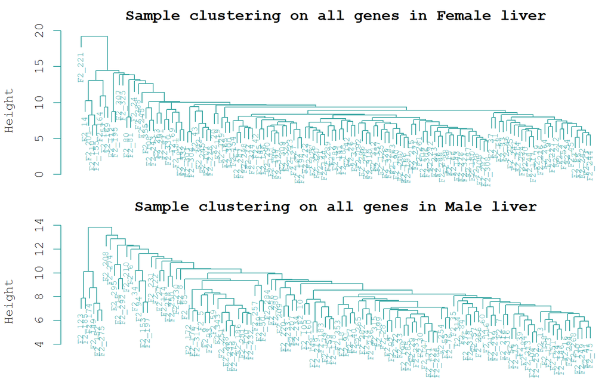

```r
par(mfrow=c(2,1))
par(mar = c(0, 4, 2, 0))
for (set in 1:nSets)
plot(sampleTrees[[set]], main = paste("Sample clustering on all genes in", setLabels[set]),
xlab="", sub="", cex = 0.7, col = "#39A6A3", family = "mono")
```

En los dendrogramas de los genes de las hembras se observa un valor atípico, el F2_221, a diferencia de los genes de los machos. Se elimina ese valor atípico por medio de un código semi-automático haciendo un corte de altura. Se repiten los de dendrogramas.

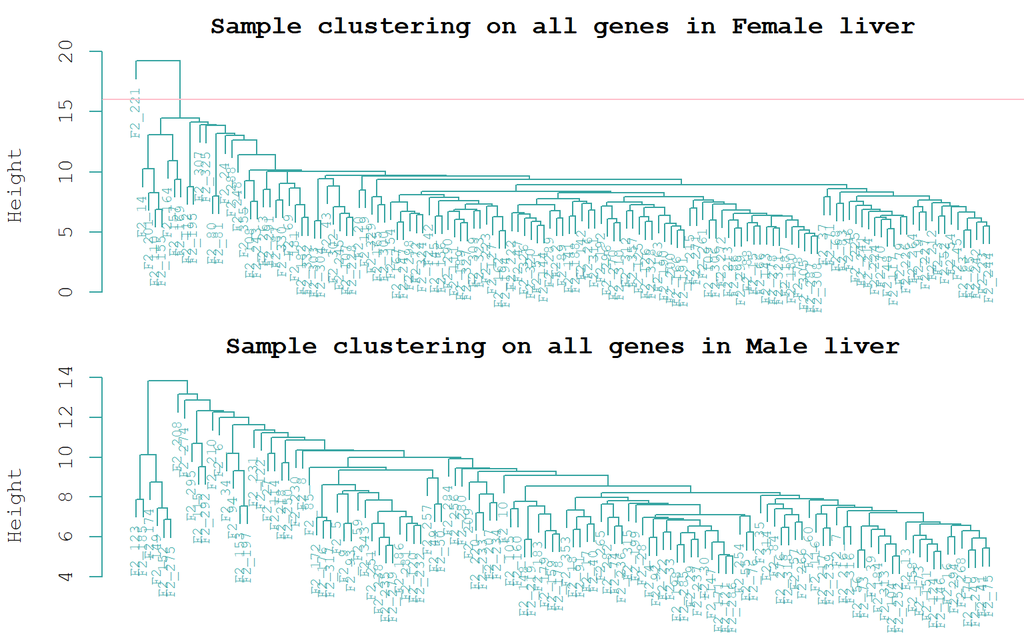

```r
# Escoger la "base" que se va a cortar

baseHeight <- 16

cutHeights <- c(16, 16*exprSize$nSamples[2]/exprSize$nSamples[1]);

# Re-plot los dendrogramas incluyendo las lineas cortadas
par(mfrow=c(2,1))
par(mar = c(0, 4, 2, 0))
for (set in 1:nSets) {
plot(sampleTrees[[set]], main = paste("Sample clustering on all genes in", setLabels[set]),
xlab="", sub="", cex = 0.7, col = "#39A6A3", family = "mono")
abline(h=cutHeights[set], col = "pink")
}
```

La línea de corte se observa de color rosa.

```r
for (set in 1:nSets) {
# Encontrar los clusters cortados por la línea
labels <- cutreeStatic(sampleTrees[[set]], cutHeight = cutHeights[set])
keep <- (labels==1)
multiExpr[[set]]$data = multiExpr[[set]]$data[keep, ]
}

collectGarbage()
# Checar el tamanno
exprSize <- checkSets(multiExpr)
exprSize
```

```
## $nSets
## [1] 2
##
## $nGenes
## [1] 3600
##
## $nSamples
## [1] 134 124
##
## $structureOK
## [1] TRUE
```

### **1c. Carga de la base de datos de rasgos clínicos**

```r
# Cargar la libreria
clinical_traits <- read.csv("ClinicalTraits.csv");

# Dimensiones de la base
dim(clinical_traits)
```

```
## [1] 361  38
```

```r
# Nombres
names(clinical_traits)
```

```
##  [1] "X"                  "Mice"               "Number"
##  [4] "Mouse_ID"           "Strain"             "sex"
##  [7] "DOB"                "parents"            "Western_Diet"
## [10] "Sac_Date"           "weight_g"           "length_cm"
## [13] "ab_fat"             "other_fat"          "total_fat"
## [16] "comments"           "X100xfat_weight"    "Trigly"
## [19] "Total_Chol"         "HDL_Chol"           "UC"
## [22] "FFA"                "Glucose"            "LDL_plus_VLDL"
## [25] "MCP_1_phys"         "Insulin_ug_l"       "Glucose_Insulin"
## [28] "Leptin_pg_ml"       "Adiponectin"        "Aortic.lesions"
## [31] "Note"               "Aneurysm"           "Aortic_cal_M"
## [34] "Aortic_cal_L"       "CoronaryArtery_Cal" "Myocardial_cal"
## [37] "BMD_all_limbs"      "BMD_femurs_only"
```

Remover las columnas con informacion no necesaria

```r
allTraits <- clinical_traits[, -c(31, 16)]

allTraits <- allTraits[, c(2, 11:36) ]

# Dimensiones, nombres y muestras

dim(allTraits)
```

```
## [1] 361  27
```

```r
names(allTraits)
```

```
##  [1] "Mice"               "weight_g"           "length_cm"
##  [4] "ab_fat"             "other_fat"          "total_fat"
##  [7] "X100xfat_weight"    "Trigly"             "Total_Chol"
## [10] "HDL_Chol"           "UC"                 "FFA"
## [13] "Glucose"            "LDL_plus_VLDL"      "MCP_1_phys"
## [16] "Insulin_ug_l"       "Glucose_Insulin"    "Leptin_pg_ml"
## [19] "Adiponectin"        "Aortic.lesions"     "Aneurysm"
## [22] "Aortic_cal_M"       "Aortic_cal_L"       "CoronaryArtery_Cal"
## [25] "Myocardial_cal"     "BMD_all_limbs"      "BMD_femurs_only"
```

```r
allTraits$Mice
```

```
##   [1] "F2_290"  "F2_291"  "F2_292"  "F2_293"  "F2_294"  "F2_295"  "F2_296"
##   [8] "F2_297"  "F2_298"  "F2_299"  "F2_300"  "F2_301"  "F2_302"  "F2_303"
##  [15] "F2_304"  "F2_305"  "F2_306"  "F2_307"  "F2_308"  "F2_309"  "F2_310"
##  [22] "F2_311"  "F2_312"  "F2_313"  "F2_314"  "F2_315"  "F2_316"  "F2_259"
##  [29] "F2_260"  "F2_261"  "F2_262"  "F2_263"  "F2_264"  "F2_265"  "F2_266"
##  [36] "F2_267"  "F2_268"  "F2_269"  "F2_270"  "F2_271"  "F2_272"  "F2_273"
##  [43] "F2_274"  "F2_275"  "F2_276"  "F2_277"  "F2_278"  "F2_279"  "F2_280"
##  [50] "F2_281"  "F2_282"  "F2_283"  "F2_284"  "F2_285"  "F2_286"  "F2_287"
##  [57] "F2_231"  "F2_232"  "F2_233"  "F2_234"  "F2_235"  "F2_236"  "F2_237"
##  [64] "F2_238"  "F2_239"  "F2_240"  "F2_241"  "F2_242"  "F2_243"  "F2_244"
##  [71] "F2_245"  "F2_246"  "F2_247"  "F2_248"  "F2_249"  "F2_250"  "F2_251"
##  [78] "F2_252"  "F2_253"  "F2_254"  "F2_255"  "F2_256"  "F2_257"  "F2_258"
##  [85] "F2_40"   "F2_41"   "F2_42"   "F2_43"   "F2_44"   "F2_45"   "F2_46"
##  [92] "F2_47"   "F2_48"   "F2_49"   "F2_50"   "F2_51"   "F2_52"   "F2_53"
##  [99] "F2_54"   "F2_55"   "F2_56"   "F2_57"   "F2_58"   "F2_59"   "F2_84"
```

[output cut: 37 more lines]

Filtrado de datos clínicos.

```r
Traits <- vector(mode="list", length = nSets)

for (set in 1:nSets){
setSamples <- rownames(multiExpr[[set]]$data)
traitRows <- match(setSamples, allTraits$Mice)
Traits[[set]] = list(data = allTraits[traitRows, -1])
rownames(Traits[[set]]$data) = allTraits[traitRows, 1]
}

collectGarbage()
```

Definir las dimensiones del conjunto de datos.

```r
nGenes <- exprSize$nGenes

nSamples = exprSize$nSamples
```

Guardar los datos para ser utilizados después.

```r
save(multiExpr, Traits, nGenes, nSamples, setLabels, shortLabels, exprSize, file = "Consensus_dataInput.RData")
```

## 2. Análisis de redes de consenso de los datos de expresión del hígado de ratones hembras y machos

### **2a. Construcción en un paso y detección de módulos**

Cargar los datos generados previamente.

```r
lnames <- load(file = "Consensus_dataInput.RData")
```

Nombres de las variables que contienen los datos y números de sets.

```r
lnames
```

```
## [1] "multiExpr"   "Traits"      "nGenes"      "nSamples"    "setLabels"
## [6] "shortLabels" "exprSize"
```

```r
nSets <- checkSets(multiExpr)$nSets
```

### **2a1. Elección de la potencia de umbralización**

```r
# Elegir conjuntos de potencias

powers <- c(seq(4,10,by=1), seq(12,20, by=2))

# Crear una lista

powerTables = vector(mode = "list", length = nSets)

# Analisis de la topologia de la red

for (set in 1:nSets)
powerTables[[set]] = list(data = pickSoftThreshold(multiExpr[[set]]$data, powerVector=powers,
verbose = 2)[[2]])
```

```
## pickSoftThreshold: will use block size 3600.
##  pickSoftThreshold: calculating connectivity for given powers...
##    ..working on genes 1 through 3600 of 3600
```

```
##    Power SFT.R.sq slope truncated.R.sq mean.k. median.k. max.k.
## 1      4    0.506 -1.42          0.973   56.50   47.2000  202.0
## 2      5    0.681 -1.72          0.940   32.20   25.1000  134.0
## 3      6    0.902 -1.50          0.962   19.90   14.5000   94.8
## 4      7    0.921 -1.67          0.917   13.20    8.6800   84.1
## 5      8    0.904 -1.72          0.876    9.25    5.3900   76.3
## 6      9    0.859 -1.70          0.836    6.80    3.5600   70.5
## 7     10    0.833 -1.66          0.831    5.19    2.3800   65.8
## 8     12    0.853 -1.48          0.911    3.33    1.1500   58.1
## 9     14    0.876 -1.38          0.949    2.35    0.5740   51.9
## 10    16    0.907 -1.30          0.970    1.77    0.3090   46.8
## 11    18    0.912 -1.24          0.973    1.39    0.1670   42.5
## 12    20    0.931 -1.21          0.977    1.14    0.0951   38.7
## pickSoftThreshold: will use block size 3600.
##  pickSoftThreshold: calculating connectivity for given powers...
##    ..working on genes 1 through 3600 of 3600
##    Power SFT.R.sq slope truncated.R.sq mean.k. median.k. max.k.
## 1      4    0.577 -1.58          0.938   51.30   45.1000  196.0
## 2      5    0.630 -1.68          0.926   29.10   23.4000  132.0
## 3      6    0.861 -1.36          0.968   17.90   12.9000   91.8
## 4      7    0.903 -1.52          0.932   11.90    7.5200   79.6
## 5      8    0.908 -1.61          0.889    8.28    4.5600   72.0
## 6      9    0.895 -1.62          0.867    6.07    2.8800   66.2
## 7     10    0.882 -1.59          0.868    4.63    1.9000   61.3
## 8     12    0.890 -1.49          0.904    2.96    0.8760   53.5
## 9     14    0.931 -1.38          0.958    2.09    0.4370   47.3
## 10    16    0.954 -1.31          0.980    1.57    0.2270   42.1
## 11    18    0.970 -1.26          0.984    1.24    0.1190   37.7
## 12    20    0.984 -1.22          0.995    1.01    0.0642   33.9
```

```r
collectGarbage()
```

Plot de los resultados

```r
colors <- c("#79018C", "#072227")

plotCols <- c(2,5,6,7)

colNames <- c("Ajuste del modelo", "Promedio de la Conectividad", "Mediana de la Conectvidad", "Conectividad Máxima")

# Minimos y max puntos

ylim <- matrix(NA, nrow = 2, ncol = 4);
for (set in 1:nSets){
for (col in 1:length(plotCols)){
ylim[1, col] = min(ylim[1, col], powerTables[[set]]$data[, plotCols[col]], na.rm = TRUE);
ylim[2, col] = max(ylim[2, col], powerTables[[set]]$data[, plotCols[col]], na.rm = TRUE);
}
 }

sizeGrWindow(8, 6)
```

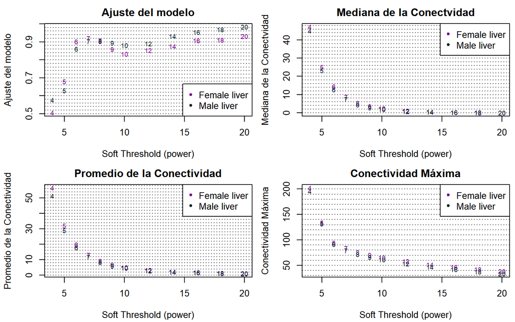

```r
par(mfcol = c(2,2))

par(mar = c(4.2, 4.2 , 2.2, 0.5))

cex1 <- 0.7

for (col in 1:length(plotCols)) for (set in 1:nSets){
if (set==1){
plot(powerTables[[set]]$data[,1], -sign(powerTables[[set]]$data[,3])*powerTables[[set]]$data[,2],
xlab="Soft Threshold (power)",ylab=colNames[col],type="n", ylim = ylim[, col],
main = colNames[col])
addGrid()
}
if (col==1){
text(powerTables[[set]]$data[,1], -sign(powerTables[[set]]$data[,3])*powerTables[[set]]$data[,2],
labels=powers,cex=cex1,col=colors[set]);
} else
text(powerTables[[set]]$data[,1], powerTables[[set]]$data[,plotCols[col]],
labels=powers,cex=cex1,col=colors[set]);
if (col==1){
legend("bottomright", legend = setLabels, col = colors, pch = 20) ;
} else
legend("topright", legend = setLabels, col = colors, pch = 20) ;
}
```

### **2a2. Construcción de redes y detección de módulos de consenso**

```r
net <- blockwiseConsensusModules(
multiExpr, power = 6, minModuleSize = 30, deepSplit = 2,
pamRespectsDendro = FALSE,
mergeCutHeight = 0.25, numericLabels = TRUE,
minKMEtoStay = 0,
saveTOMs = TRUE, verbose = 5)
```

```
##  Calculating consensus modules and module eigengenes block-wise from all genes
##  Calculating topological overlaps block-wise from all genes
##    Flagging genes and samples with too many missing values...
##     ..step 1
##      ..bad gene count: 0, bad sample counts: 0, 0
##  ....Working on set 1
##     TOM calculation: adjacency..
##     ..will not use multithreading.
##      Fraction of slow calculations: 0.396405
##     ..connectivity..
##     ..matrix multiplication (system BLAS)..
##     ..normalization..
##     ..done.
##  ....Working on set 2
##     TOM calculation: adjacency..
##     ..will not use multithreading.
##      Fraction of slow calculations: 0.438385
##     ..connectivity..
##     ..matrix multiplication (system BLAS)..
##     ..normalization..
##     ..done.
## Cluster size 3600 broken into 2108 1492
## Cluster size 2108 broken into 1126 982
## Done cluster 1126
## Done cluster 982
## Done cluster 2108
## Done cluster 1492
## Cluster size 3600 broken into 1576 2024
## Cluster size 1576 broken into 694 882
## Done cluster 694
## Done cluster 882
## Done cluster 1576
## Cluster size 2024 broken into 1045 979
## Done cluster 1045
## Done cluster 979
## Done cluster 2024
##  ..Working on block 1 .
##  ....Working on set 1
##  ....Working on set 2
##  ....Calculating consensus network
```

[output cut: 15 more lines]

```
##          Working on set 1 ...
##          moduleEigengenes: Calculating 20 module eigengenes in given set.
##          Working on set 2 ...
##          moduleEigengenes: Calculating 20 module eigengenes in given set.
##        multiSetMEs: Calculating module MEs.
##          Working on set 1 ...
##          moduleEigengenes: Calculating 18 module eigengenes in given set.
##          Working on set 2 ...
##          moduleEigengenes: Calculating 18 module eigengenes in given set.
##        Calculating new MEs...
##        multiSetMEs: Calculating module MEs.
##          Working on set 1 ...
##          moduleEigengenes: Calculating 18 module eigengenes in given set.
##          Working on set 2 ...
##          moduleEigengenes: Calculating 18 module eigengenes in given set.
```

```r
# Los nombres de los componentes

names(net)
```

```
##  [1] "colors"                    "unmergedColors"
##  [3] "multiMEs"                  "goodSamples"
##  [5] "goodGenes"                 "dendrograms"
##  [7] "TOMFiles"                  "blockGenes"
##  [9] "blocks"                    "originCount"
## [11] "networkCalibrationSamples" "individualTOMInfo"
## [13] "consensusTOMInfo"          "consensusQuantile"
```

**Dendrogramas**.

```r
consMEs <- net$multiMEs

moduleLabels <- net$colors

# Convertir las etiquetas numéricas en etiquetas de color

moduleColors <- labels2colors(moduleLabels)

consTree <- net$dendrograms[[1]]

sizeGrWindow(8,6)

plotDendroAndColors(consTree, moduleColors, "Module colors",
dendroLabels = FALSE, hang = 0.03, addGuide = TRUE, guideHang = 0.05,
main = "Consensus gene dendrogram and module colors", family = "mono")
```

[output not shown]

Guardar los datos.

```r
save(consMEs, moduleLabels, moduleColors, consTree, file = "Consensus_NetworkConstruction_auto.RData")
```

## 3. Relacionar los módulos consenso con los módulos específicos de los conjuntos femeninos

Cargar los datos previos.

```r
# De la parte uno

lnames <- load(file = "Consensus_dataInput.RData")
lnames
```

```
## [1] "multiExpr"   "Traits"      "nGenes"      "nSamples"    "setLabels"
## [6] "shortLabels" "exprSize"
```

```r
# De la parte dos

lnames <- load(file = "Consensus_NetworkConstruction_auto.RData")
lnames
```

```
## [1] "consMEs"      "moduleLabels" "moduleColors" "consTree"
```

Cargar los datos de hígado de ratón hembra.

```r
lnames <- load("FemaleLiver_02_networkConstruction_auto.RData")
lnames
```

```
## [1] "MEs"          "moduleLabels" "moduleColors" "geneTree"
```

Renombrar.

```r
femaleLabels <- moduleLabels
femaleColors <- moduleColors
femaleTree <- geneTree
femaleMEs <- orderMEs(MEs, greyName = "ME0")

# Cargar de nuevo el del punto 2

lnames = load("Consensus_NetworkConstruction_auto.RData")
lnames
```

```
## [1] "consMEs"      "moduleLabels" "moduleColors" "consTree"
```

Relacionar los módulos.

```r
femModuleLabels <- substring(names(femaleMEs), 3)

consModuleLabels <- substring(names(consMEs[[1]]$data), 3)

# Convertir las etiquetas numéricas en etiquetas de color

femModules <- labels2colors(as.numeric(femModuleLabels))

consModules <- labels2colors(as.numeric(consModuleLabels))

# Numeros de modulos femeninos y de consenso

nFemMods <- length(femModules)

nConsMods <- length(consModules)

# Tablas de valores de p y recuentos correspondientes

pTable <- matrix(0, nrow = nFemMods, ncol = nConsMods)

CountTbl <- matrix(0, nrow = nFemMods, ncol = nConsMods)
```

Comparaciones pairwaise.

```r
for (fmod in 1:nFemMods)
for (cmod in 1:nConsMods){
femMembers = (femaleColors == femModules[fmod]);
consMembers = (moduleColors == consModules[cmod]);
pTable[fmod, cmod] = -log10(fisher.test(femMembers, consMembers, alternative = "greater")$p.value);
CountTbl[fmod, cmod] = sum(femaleColors == femModules[fmod] & moduleColors ==
consModules[cmod])
}
```

Tabla con código de colores de los recuentos de intersección. Colores indican valor *p*.

```r
pTable[is.infinite(pTable)] = 1.3*max(pTable[is.finite(pTable)]);

pTable[pTable>50 ] = 50

# Recuentos marginales

femModTotals <- apply(CountTbl, 1, sum)

consModTotals <- apply(CountTbl, 2, sum)

sizeGrWindow(10,7 )

# Para el plot

par(mfrow=c(1,1))

par(cex = 1.0)

par(mar=c(8, 10.4, 2.7, 1)+0.3)
```

labeledHeatmap con la tabla codificada por colores.

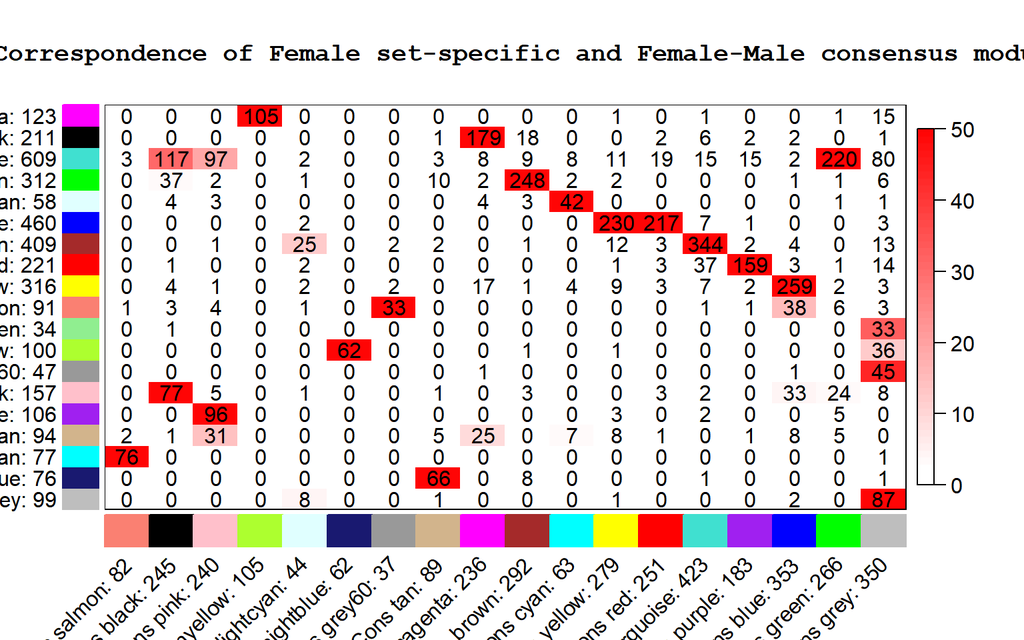

```r
labeledHeatmap(Matrix = pTable, xLabels = paste(" ", consModules),
yLabels = paste(" ", femModules), colorLabels = TRUE,
xSymbols = paste("Cons ", consModules, ": ", consModTotals, sep=""),
ySymbols = paste("Fem ", femModules, ": ", femModTotals, sep=""),
textMatrix = CountTbl, colors = greenWhiteRed(100)[50:100],
main = "Correspondence of Female set-specific and Female-Male consensus modules", cex.text = 1.0,
cex.lab = 1.0, setStdMargins = FALSE, family = "mono")
```

## 4. Relacionar los módulos de consenso con los microarreglos sa externos

Cargar los datos previos.

```r
# De la parte uno

lnames <- load(file = "Consensus_dataInput.RData")
lnames
```

```
## [1] "multiExpr"   "Traits"      "nGenes"      "nSamples"    "setLabels"
## [6] "shortLabels" "exprSize"
```

```r
# De la parte dos

lnames <- load(file = "Consensus_NetworkConstruction_auto.RData")
lnames
```

```
## [1] "consMEs"      "moduleLabels" "moduleColors" "consTree"
```

```r
exprSize <- checkSets(multiExpr)
nSets <- exprSize$nSets
```

Obtener correlaciones módulo-rasgo.

```r
moduleTraitCor <- list()

moduleTraitPvalue <- list()
```

Calcular las correlaciones.

```r
for (set in 1:nSets){
moduleTraitCor[[set]] = cor(consMEs[[set]]$data, Traits[[set]]$data, use = "p");
moduleTraitPvalue[[set]] = corPvalueFisher(moduleTraitCor[[set]], exprSize$nSamples[set]);
}

# Convertir las etiquetas numéricas en etiquetas de color

MEColors <- labels2colors(as.numeric(substring(names(consMEs[[1]]$data), 3)))
MEColorNames <- paste("ME", MEColors, sep="")

sizeGrWindow(10,7)
```

Tabla de relación módulo-rasgo para el conjunto 1.

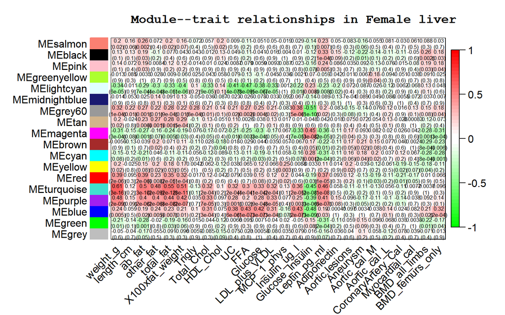

```r
set <- 1

textMatrix <- paste(signif(moduleTraitCor[[set]], 2), "\n(",
signif(moduleTraitPvalue[[set]], 1), ")", sep = "")

dim(textMatrix) = dim(moduleTraitCor[[set]])
par(mar = c(6, 8.8, 3, 2.2));
labeledHeatmap(Matrix = moduleTraitCor[[set]],
xLabels = names(Traits[[set]]$data),
yLabels = MEColorNames,
ySymbols = MEColorNames,
colorLabels = FALSE,
colors = greenWhiteRed(50),
textMatrix = textMatrix,
setStdMargins = FALSE,
cex.text = 0.5,
zlim = c(-1,1),
family = "mono",
main = paste("Module--trait relationships in", setLabels[set]))
```

Tabla de relación módulo-rasgo para el conjunto 2.

```r
set <- 2

textMatrix <- paste(signif(moduleTraitCor[[set]], 2), "\n(",
signif(moduleTraitPvalue[[set]], 1), ")", sep = "")

dim(textMatrix) = dim(moduleTraitCor[[set]])
sizeGrWindow(10,7)

par(mar = c(6, 8.8, 3, 2.2))

labeledHeatmap(Matrix = moduleTraitCor[[set]],
xLabels = names(Traits[[set]]$data),
yLabels = MEColorNames,
ySymbols = MEColorNames,
colorLabels = FALSE,
colors = greenWhiteRed(50),
textMatrix = textMatrix,
setStdMargins = FALSE,
cex.text = 0.5,
zlim = c(-1,1),
family = "mono",
main = paste("Module--trait relationships in", setLabels[set]))
```

[output not shown]

Correlación de consenso y el valor *p*.

```r
consensusCor <- matrix(NA, nrow(moduleTraitCor[[1]]), ncol(moduleTraitCor[[1]]))

consensusPvalue <- matrix(NA, nrow(moduleTraitCor[[1]]), ncol(moduleTraitCor[[1]]))

# Correlaciones negativas de consenso

negative <- moduleTraitCor[[1]] < 0 & moduleTraitCor[[2]] < 0

consensusCor[negative] = pmax(moduleTraitCor[[1]][negative], moduleTraitCor[[2]][negative])

consensusPvalue[negative] = pmax(moduleTraitPvalue[[1]][negative], moduleTraitPvalue[[2]][negative])

# Correlaciones positivas de consenso

positive <- moduleTraitCor[[1]] > 0 & moduleTraitCor[[2]] > 0

consensusCor[positive] = pmin(moduleTraitCor[[1]][positive], moduleTraitCor[[2]][positive])

consensusPvalue[positive] = pmax(moduleTraitPvalue[[1]][positive], moduleTraitPvalue[[2]][positive])
```

Relaciones consensuadas entre módulos y rasgos en una tabla codificada por colores.

```r
textMatrix <- paste(signif(consensusCor, 2), "\n(",
signif(consensusPvalue, 1), ")", sep = "")

dim(textMatrix) = dim(moduleTraitCor[[set]])

sizeGrWindow(10,7)

par(mar = c(6, 8.8, 3, 2.2));
labeledHeatmap(Matrix = consensusCor,
xLabels = names(Traits[[set]]$data),
yLabels = MEColorNames,
ySymbols = MEColorNames,
colorLabels = FALSE,
colors = greenWhiteRed(50),
textMatrix = textMatrix,
setStdMargins = FALSE,
cex.text = 0.5,
zlim = c(-1,1),
family = "mono",
main = paste("Consensus module--trait relationships across\n",
paste(setLabels, collapse = " and ")))
```

[output not shown]

### **4a. Exportar los resultados del análisis de la red**

```r
annot <- read.csv("GeneAnnotation.csv")

probes <- names(multiExpr[[1]]$data)

probes2annot <- match(probes, annot$substanceBXH)
```

Re-calcular los eigengenes de los módulos.

```r
consMEs.unord <- multiSetMEs(multiExpr, universalColors = moduleLabels, excludeGrey = TRUE)
```

```
##  multiSetMEs: Calculating module MEs.
##    Working on set 1 ...
##    Working on set 2 ...
```

```r
GS <- list()

kME <- list()

for (set in 1:nSets){
GS[[set]] = corAndPvalue(multiExpr[[set]]$data, Traits[[set]]$data);
kME[[set]] = corAndPvalue(multiExpr[[set]]$data, consMEs.unord[[set]]$data);
}
```

Meta-análisis, formar puntuación Z y valor de *p*.

```r
GS.metaZ <- (GS[[1]]$Z + GS[[2]]$Z)/sqrt(2)

kME.metaZ <- (kME[[1]]$Z + kME[[2]]$Z)/sqrt(2)

GS.metaP <- 2*pnorm(abs(GS.metaZ), lower.tail = FALSE)

kME.metaP <- 2*pnorm(abs(kME.metaZ), lower.tail = FALSE)
```

Matrices con GS y kME.

```r
GSmat <- rbind(GS[[1]]$cor, GS[[2]]$cor, GS[[1]]$p, GS[[2]]$p, GS.metaZ, GS.metaP)

nTraits <-  checkSets(Traits)$nGenes

traitNames <- colnames(Traits[[1]]$data)

dim(GSmat) <- c(nGenes, 6*nTraits)

rownames(GSmat) = probes

colnames(GSmat) = spaste(
c("GS.set1.", "GS.set2.", "p.GS.set1.", "p.GS.set2.", "Z.GS.meta.", "p.GS.meta"), rep(traitNames, rep(6, nTraits)))


kMEmat <- rbind(kME[[1]]$cor, kME[[2]]$cor, kME[[1]]$p, kME[[2]]$p, kME.metaZ, kME.metaP)

MEnames <- colnames(consMEs.unord[[1]]$data)

nMEs <- checkSets(consMEs.unord)$nGenes

dim(kMEmat) <- c(nGenes, 6*nMEs)

rownames(kMEmat) = probes

colnames(kMEmat) = spaste(
c("kME.set1.", "kME.set2.", "p.kME.set1.", "p.kME.set2.", "Z.kME.meta.", "p.kME.meta"), rep(MEnames, rep(6, nMEs)))
```

Juntar los datos y guardarlos.

```r
info <- data.frame(Probe = probes, GeneSymbol = annot$gene_symbol[probes2annot],
EntrezID = annot$LocusLinkID[probes2annot],
ModuleLabel = moduleLabels,
ModuleColor = labels2colors(moduleLabels),
GSmat,
kMEmat)

# Guardar archivo csv

write.csv(info, file = "consensusAnalysis_CombinedNetworkResults.csv",
row.names = FALSE, quote = FALSE)
```

## 5. Comparación de las redes de eigenes en ratones machos y hembras

Variable de peso, solo peso corporal de los ratones

```r
weight <- vector(mode = "list", length = nSets)

for (set in 1:nSets){
weight[[set]] = list(data = as.data.frame(Traits[[set]]$data$weight_g))

names(weight[[set]]$data) = "weight"
}

# Recalcular consMEs para darles nombres de colores

consMEsC <- multiSetMEs(multiExpr, universalColors = moduleColors)
```

```
##  multiSetMEs: Calculating module MEs.
##    Working on set 1 ...
##    Working on set 2 ...
```

```r
# Agregar rasgo de peso a los eigengenes

MET <- consensusOrderMEs(addTraitToMEs(consMEsC, weight))
```

Realizar análisis diferencial con la función

**plotEigengeneNetworks**

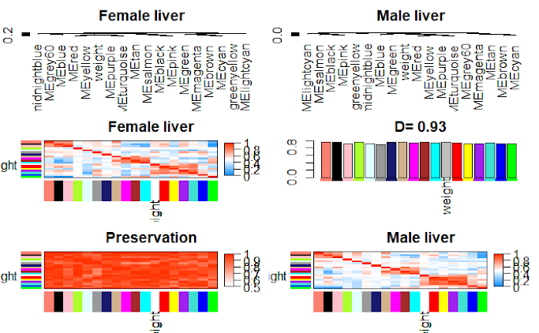

```r
sizeGrWindow(6,7)

par(cex = 0.9)

plotEigengeneNetworks(MET, setLabels, marDendro = c(0,2,2,1), marHeatmap = c(3,3,2,1),
zlimPreservation = c(0.5, 1), xLabelsAngle = 90)
```

## 6. Exportación de una red de genes a un software externo

Cargar los datos previos.

```r
# De la parte uno

lnames <- load(file = "FemaleLiver_01_dataInput.RData")
lnames
```

```
## [1] "datExpr"   "datTraits"
```

```r
# De la parte dos

lnames <- load(file = "FemaleLiver_02_networkConstruction_auto.RData")
lnames
```

```
## [1] "MEs"          "moduleLabels" "moduleColors" "geneTree"
```

### **6a. Exportar a Cytoscape**

```r
# Recalcular solapamiento

TOM <- TOMsimilarityFromExpr(datExpr, power = 6)
```

```
## TOM calculation: adjacency..
## ..will not use multithreading.
##  Fraction of slow calculations: 0.396405
## ..connectivity..
## ..matrix multiplication (system BLAS)..
## ..normalization..
## ..done.
```

```r
# Cargar datos de anotacion

annot <- read.csv("GeneAnnotation.csv")

# Seleccionar los modulos

modules <- c("brown", "red")

# Seleccionar sondas del modulo

probes <- names(datExpr)

inModule <- is.finite(match(moduleColors, modules))

modProbes <- probes[inModule]

modGenes <- annot$gene_symbol[match(modProbes, annot$substanceBXH)]

# Seleccionar el solapamiento toplogico correspondiente

modTOM <- TOM[inModule, inModule]

dimnames(modTOM) = list(modProbes, modProbes)

# Exportar la red para Cytoscape

cyt <-  exportNetworkToCytoscape(modTOM,
edgeFile = paste("CytoscapeInput-edges-", paste(modules, collapse="-"), ".txt", sep=""),
nodeFile = paste("CytoscapeInput-nodes-", paste(modules, collapse="-"), ".txt", sep=""),
weighted = TRUE, threshold = 0.02, nodeNames = modProbes,
altNodeNames = modGenes, nodeAttr = moduleColors[inModule])
```

### **Red en Cytoscape**

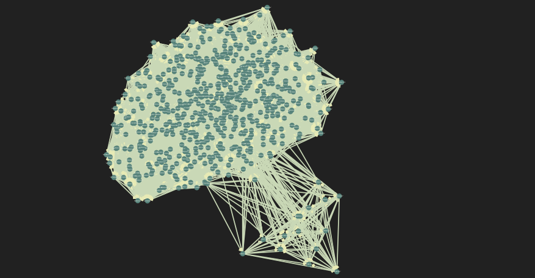

# **c) Preguntas**

**i. ¿En dónde está el objeto de matriz de expresión y de qué dimensión es?**

En la parte 2a, cuando se hace la elección de la potencia de umbralización y después se construye la red, no estoy muy segura :c

**ii. ¿Por qué se eliminan datos que son demasiado distintos?**

Para evitar que estos datos generen datos, como outliers y sea un estudio más limpio.

**iii. ¿Qué criterio utilizan para generar la red, es decir explica el significado de la variable softpower?**

Genera las conexiones entre los pares de genes.

**iv. ¿Por qué crees que genes del mismo clúster son relevantes?**

Porque pueden tener una función relacionada.

**v. Discute algunos de los resultados que te parezcan interesantes de los clústers**

Los clústers al eliminar los datos demasiado distintos se pueden visualizar de una mejor forma, además de que a simple vista se ven más elementos en lo clústers de las hembras, que de los machos los cuales se ven un poco más dispersos y con más distancia entre ellos.